# HW2

## Part 2: EDA

The column Borough contains the Borough of each property and is one of either Bronx, Manhattan, Staten Island, Brooklyn, or Queens.

1. Plot property logValue against property logUnits. Name the x and y labels of the plot appropriately. logValue should be on the y-axis.

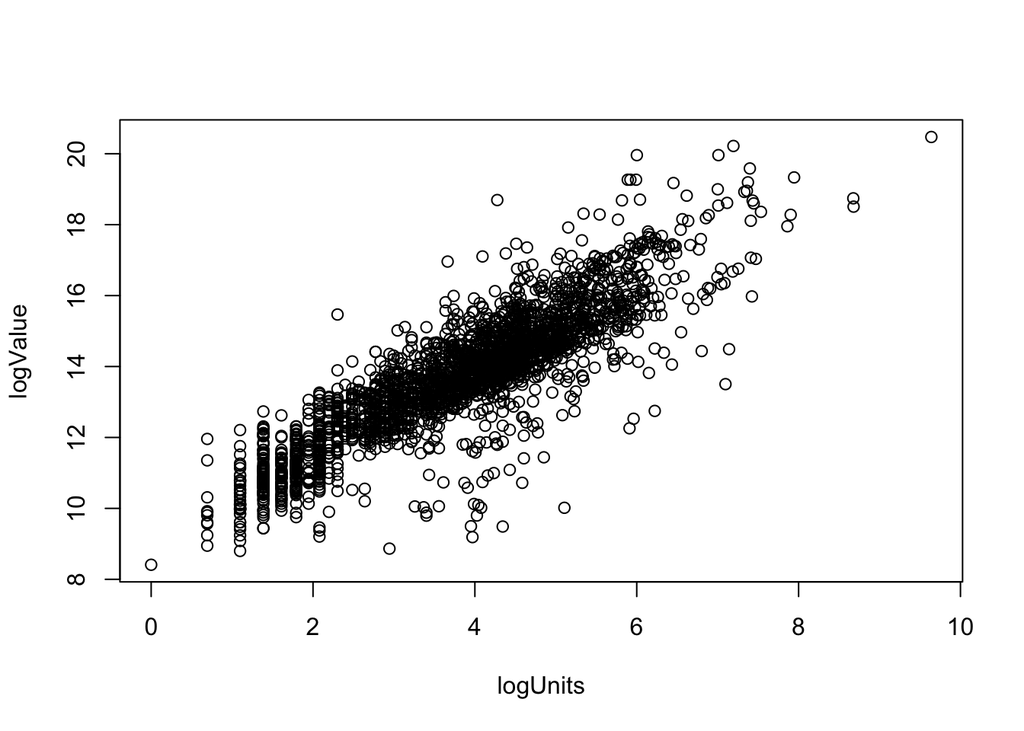

```r
plot(housing_subset$logUnits,housing_subset$logValue,xlab = "logUnits",ylab = "logValue")
```

ii. Make the same plot as above,but now include the argument col = factor(housing$after1950). Describe this plot and the covariation between the two variables. What does the coloring in the plot tell us? Hint: legend("bottomright", legend = levels(factor(housing$after1950)), fill = unique(factor(housing$after1950))).

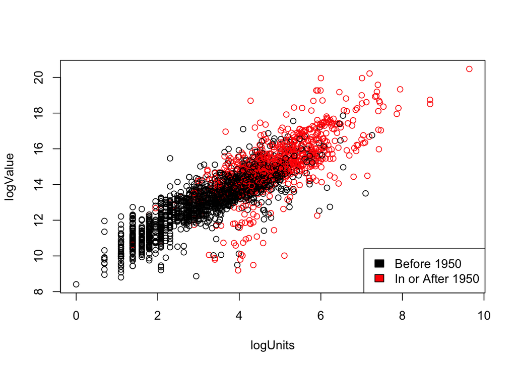

```r
plot(housing_subset$logUnits,housing_subset$logValue,xlab = "logUnits",ylab = "logValue",col = factor(housing_subset$after1950))
legend("bottomright", legend = c("Before 1950","In or After 1950"), fill = unique(factor(housing_subset$after1950)))
```

```r
#Houses that built in or after 1950 are now red labeled and differentiated from the others.The graph also shows that the units and housing price is positive correlated. In general,the more units a house has, the higher price it is.

#The plot shows that the covariance between the two variables are positive

#The coloring tells us that the price of the house is positive correlated with the yearbuild and units it has. In general, a newer house will have higher price.
```

3. The cor() function calculates the correlation coefficient between two variables. What is the correlation between property logValue and property logUnits in (i) the whole data, (ii) just Manhattan (iii) just Brooklyn (iv) for properties built after 1950 (v) for properties built before 1950?

```r
cor(housing_subset$logValue,housing_subset$logUnits)
```

```
## [1] 0.8727348
```

```r
cor(housing_subset[housing_subset$Borough == "Manhattan","logValue"],housing_subset[housing_subset$Borough == "Manhattan","logUnits"])
```

```
## [1] 0.8830348
```

```r
cor(housing_subset[housing_subset$Borough == "Brooklyn","logValue"],housing_subset[housing_subset$Borough == "Brooklyn","logUnits"])
```

```
## [1] 0.9102601
```

```r
cor(housing_subset[housing_subset$after1950 == "TRUE","logValue"], housing_subset[housing_subset$after1950 == "TRUE","logUnits"])
```

```
## [1] 0.721735
```

```r
cor(housing_subset[housing_subset$after1950 == "FALSE","logValue"],housing_subset[housing_subset$after1950 == "FALSE","logUnits"])
```

```
## [1] 0.8643297
```

```r
# Cor1: 0.8727348; Cor2: 0.8830348; Cor3: 0.9102601; Cor4: 0.721735; Cor5: 0.8643297
```

4. Make a single plot showing property logValue against property logUnits for Manhattan and Brooklyn. When creating this plot, clearly distinguish the two boroughs.

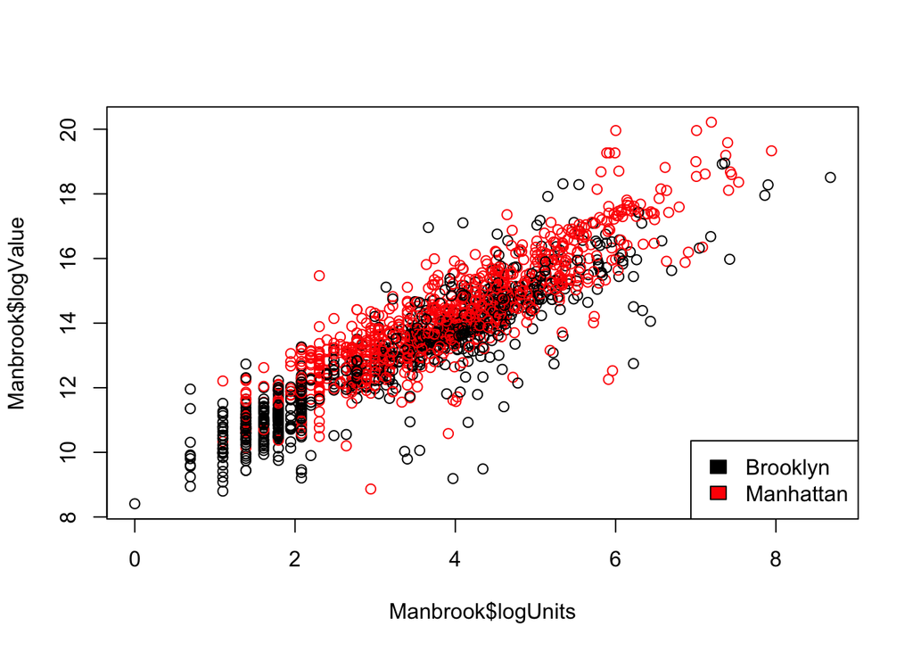

```r
Manbrook<-housing_subset[housing_subset$Borough == "Manhattan"|housing_subset$Borough == "Brooklyn",]
plot(Manbrook$logUnits,Manbrook$logValue,col=as.factor(Manbrook$Borough))
legend("bottomright", legend = levels(factor(Manbrook$Borough)), fill = 1:length(unique(factor(Manbrook$Borough))))
```

22. Consider the following block of code. Give a single line of R code which gives the same final answer as the block of code. There are a few ways to do this.

```r
    manhat.props <- c()
    for (props in 1:nrow(housing)) {
      if (housing$Borough[props] == "Manhattan") {
        manhat.props <- c(manhat.props, props)
      }
}
    med.value <- c()
    for (props in manhat.props) {
      med.value <- c(med.value, housing$Value[props])
    }
    med.value <- median(med.value, na.rm = TRUE)
```

```r
median(housing_subset$Value[housing_subset$Borough=="Manhattan"],na.rm=TRUE)
```

```
## [1] 1172362
```

6. Make side-by-side box plots comparing property logValue across the five boroughs.

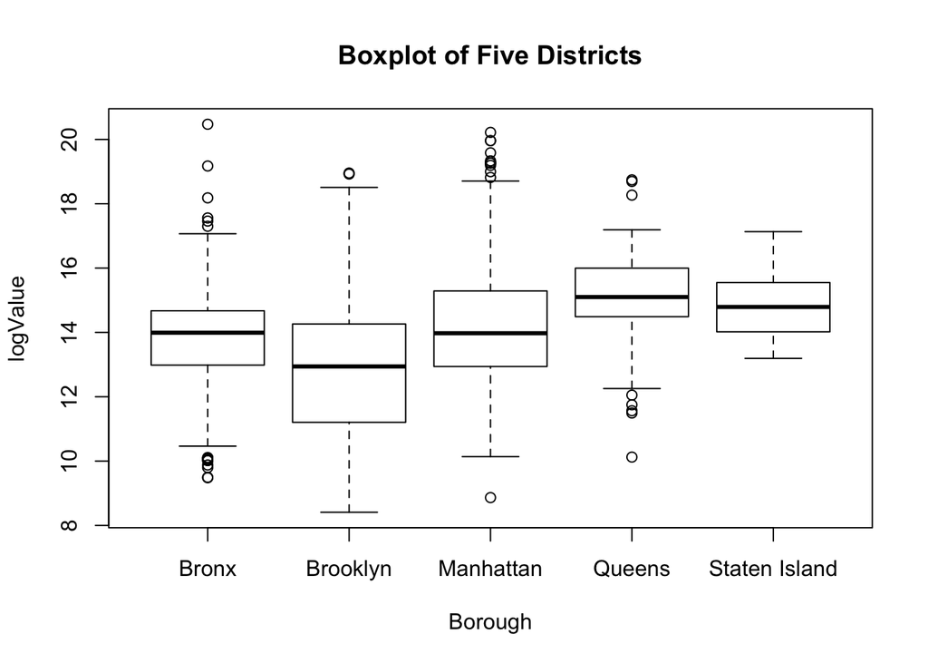

```r
boxplot(housing_subset$logValue~housing_subset$Borough,xlab="Borough",ylab="logValue")
title("Boxplot of Five Districts")
```

7. For five boroughs, what are the median property values? (Use Value here, not logValue.)

```r
tapply(housing_subset$Value,housing_subset$Borough,median)
```

```
##         Bronx      Brooklyn     Manhattan        Queens Staten Island
##       1192950        417610       1172362       3611700       2654100
```